# Chicago Homicide Rate

## A look at the Chicago homicide rate from 2001 to present

Author: Kevin Ghorbani

```python
from collections import Counter
import datetime
from dateutil import parser
import matplotlib
import matplotlib.pylab as plt
import numpy as np
import pandas as pd
import pickle
import scipy
import scipy.odr
import time
import warnings
```

```python
%matplotlib inline
```

City of Chicago has the raw data from its police departmet available on its website. You can have access to the data from Jan 2001 to present (https://data.cityofchicago.org/Public-Safety/Crimes-2001-to-present/ijzp-q8t2/data).

I'm loading the data from 01/01/2001 to 07/27/2017 where nearly 6.4 million crimes has been recorded by Chicago Police.

```python
df = pd.read_csv('C_-_2001_to_present.csv')
```

'Date' in csv date needs to be converted from 'string' to 'datetime' and will be saved to a pickle file for convenience for late use.

```python
column = df['Date']
column = pd.to_datetime(column, coerce=True)
df['Date'] = column

pickle.dump(column, open('c-2001-present_date.p', 'wb'))
```

Loading the already saved 'datetime' from a pickle file.

```python
df['Date'] = pickle.load(open('c-2001-present_date.p', 'rb'))
```

This is how the data frame looks like.

```python
df
```

|  | ID | Case Number | Date | Block | IUCR | Primary Type | Description | Location Description | Arrest | Domestic | ... | Ward | Community Area | FBI Code | X Coordinate | Y Coordinate | Year | Updated On | Latitude | Longitude | Location |
| --- | --- | --- | --- | --- | --- | --- | --- | --- | --- | --- | --- | --- | --- | --- | --- | --- | --- | --- | --- | --- | --- |
| 0 | 4473386 | HL773065 | 11/14/2005 05:00:00 PM | 001XX S CLINTON ST | 1150 | DECEPTIVE PRACTICE | CREDIT CARD FRAUD | RESTAURANT | False | False | ... | 2.0 | 28.0 | 11 | 1172750.0 | 1899670.0 | 2005 | 04/15/2016 08:55:02 AM | 41.880131 | -87.641141 | (41.880131389, -87.641140619) |
| 1 | 4473387 | HL701555 | 10/28/2005 09:27:23 PM | 005XX S KEDZIE AVE | 1811 | NARCOTICS | POSS: CANNABIS 30GMS OR LESS | CTA PLATFORM | True | False | ... | 24.0 | 27.0 | 18 | 1155124.0 | 1897322.0 | 2005 | 04/15/2016 08:55:02 AM | 41.874060 | -87.705924 | (41.874060099, -87.705924314) |
| 2 | 4473388 | HL771710 | 12/04/2005 04:20:00 PM | 015XX E 55TH ST | 0860 | THEFT | RETAIL THEFT | GROCERY FOOD STORE | True | False | ... | 4.0 | 41.0 | 06 | 1187447.0 | 1868839.0 | 2005 | 04/15/2016 08:55:02 AM | 41.795192 | -87.588158 | (41.795191528, -87.588157998) |
| 3 | 4473389 | HL772913 | 12/03/2005 03:00:00 PM | 033XX W PALMER ST | 0810 | THEFT | OVER $500 | RESIDENCE | False | False | ... | 26.0 | 22.0 | 06 | 1153635.0 | 1914422.0 | 2005 | 04/15/2016 08:55:02 AM | 41.921014 | -87.710936 | (41.921013866, -87.710935793) |
| 4 | 4473390 | HL764158 | 11/29/2005 04:30:00 PM | 001XX N HOYNE AVE | 0840 | THEFT | FINANCIAL ID THEFT: OVER $300 | RESIDENCE | False | False | ... | 2.0 | 28.0 | 06 | 1162385.0 | 1901071.0 | 2005 | 04/15/2016 08:55:02 AM | 41.884199 | -87.679160 | (41.884198945, -87.679160361) |
| 5 | 4473393 | HL699700 | 10/27/2005 08:55:00 PM | 049XX W CONCORD PL | 1821 | NARCOTICS | MANU/DEL:CANNABIS 10GM OR LESS | SIDEWALK | True | False | ... | 37.0 | 25.0 | 18 | 1143101.0 | 1910515.0 | 2005 | 04/15/2016 08:55:02 AM | 41.910496 | -87.749738 | (41.910495918, -87.74973818) |
| 6 | 4473394 | HL683756 | 10/19/2005 10:21:56 PM | 037XX W IOWA ST | 2014 | NARCOTICS | MANU/DELIVER: HEROIN (WHITE) | SIDEWALK | True | False | ... | 27.0 | 23.0 | 18 | 1151363.0 | 1905746.0 | 2005 | 04/15/2016 08:55:02 AM | 41.897251 | -87.719512 | (41.897251052, -87.719511811) |
| 7 | 4473402 | HL771844 | 12/04/2005 03:00:00 AM | 051XX S HARPER AVE | 0486 | BATTERY | DOMESTIC BATTERY SIMPLE | APARTMENT | False | True | ... | 4.0 | 41.0 | 08B | 1187156.0 | 1871320.0 | 2005 | 04/15/2016 08:55:02 AM | 41.802006 | -87.589146 | (41.80200649, -87.589146319) |
| 8 | 4473403 | HL701641 | 10/28/2005 10:08:09 PM | 014XX W MORSE AVE | 1811 | NARCOTICS | POSS: CANNABIS 30GMS OR LESS | SIDEWALK | True | False | ... | 49.0 | 1.0 | 18 | 1165396.0 | 1946171.0 | 2005 | 04/15/2016 08:55:02 AM | 42.007892 | -87.666816 | (42.007892017, -87.666815826) |
| 9 | 4473404 | HL683878 | 10/20/2005 12:05:00 AM | 005XX S PULASKI RD | 1811 | NARCOTICS | POSS: CANNABIS 30GMS OR LESS | SIDEWALK | True | False | ... | 24.0 | 26.0 | 18 | 1149808.0 | 1897367.0 | 2005 | 04/15/2016 08:55:02 AM | 41.874289 | -87.725441 | (41.874288556, -87.725441164) |
| 10 | 4473408 | HL699708 | 10/27/2005 09:50:00 PM | 0000X W 113TH ST | 1811 | NARCOTICS | POSS: CANNABIS 30GMS OR LESS | STREET | True | False | ... | 34.0 | 49.0 | 18 | 1177895.0 | 1830038.0 | 2005 | 04/15/2016 08:55:02 AM | 41.688939 | -87.624357 | (41.688938759, -87.624357202) |
| 11 | 4473411 | HL773079 | 11/25/2005 09:00:00 PM | 075XX S PERRY AVE | 0820 | THEFT | $500 AND UNDER | STREET | False | False | ... | 6.0 | 69.0 | 06 | 1176697.0 | 1855088.0 | 2005 | 04/15/2016 08:55:02 AM | 41.757706 | -87.627992 | (41.757706259, -87.627991619) |
| 12 | 4473414 | HL699712 | 10/27/2005 09:20:00 PM | 027XX N NEW ENGLAND AVE | 1811 | NARCOTICS | POSS: CANNABIS 30GMS OR LESS | RESIDENCE | True | False | ... | 36.0 | 18.0 | 18 | 1129952.0 | 1917506.0 | 2005 | 04/15/2016 08:55:02 AM | 41.929915 | -87.797883 | (41.929915449, -87.797883181) |
| 13 | 4473416 | HL684635 | 10/20/2005 12:43:30 PM | 011XX N AVERS AVE | 2024 | NARCOTICS | POSS: HEROIN(WHITE) | ALLEY | True | False | ... | 27.0 | 23.0 | 18 | 1150506.0 | 1907397.0 | 2005 | 04/15/2016 08:55:02 AM | 41.901798 | -87.722616 | (41.901798344, -87.722616312) |
| 14 | 4473417 | HL773082 | 10/05/2005 12:00:00 PM | 059XX S SANGAMON ST | 0820 | THEFT | $500 AND UNDER | OTHER | False | False | ... | 16.0 | 68.0 | 06 | 1170989.0 | 1865541.0 | 2005 | 04/15/2016 08:55:02 AM | 41.786517 | -87.648606 | (41.786517079, -87.648605673) |
| 15 | 4473420 | HL699713 | 10/27/2005 09:30:00 PM | 051XX S DAMEN AVE | 2027 | NARCOTICS | POSS: CRACK | STREET | True | False | ... | 16.0 | 61.0 | 18 | 1163893.0 | 1870472.0 | 2005 | 04/15/2016 08:55:02 AM | 41.800200 | -87.674485 | (41.800200491, -87.674484772) |
| 16 | 4473423 | HL772179 | 12/04/2005 10:15:00 PM | 017XX N MAYFIELD AVE | 2092 | NARCOTICS | SOLICIT NARCOTICS ON PUBLICWAY | STREET | True | False | ... | 29.0 | 25.0 | 26 | 1136824.0 | 1910864.0 | 2005 | 04/15/2016 08:55:02 AM | 41.911568 | -87.772789 | (41.911568497, -87.772789486) |
| 17 | 4473424 | HK686401 | 10/14/2004 03:09:43 PM | 078XX S SEELEY AVE | 1661 | GAMBLING | GAME/DICE | STREET | True | False | ... | 18.0 | 71.0 | 19 | 1164059.0 | 1852588.0 | 2004 | 04/15/2016 08:55:02 AM | 41.751121 | -87.674379 | (41.751120907, -87.674378549) |
| 18 | 4473428 | HL699718 | 10/27/2005 09:45:00 PM | 012XX S INDEPENDENCE BLVD | 2024 | NARCOTICS | POSS: HEROIN(WHITE) | SIDEWALK | True | False | ... | 24.0 | 29.0 | 18 | 1151446.0 | 1894247.0 | 2005 | 04/15/2016 08:55:02 AM | 41.865695 | -87.719509 | (41.865694933, -87.719509038) |
| 19 | 4473430 | HL701977 | 10/29/2005 02:18:29 AM | 058XX W WALTON ST | 1811 | NARCOTICS | POSS: CANNABIS 30GMS OR LESS | SIDEWALK | True | False | ... | 29.0 | 25.0 | 18 | 1137247.0 | 1905739.0 | 2005 | 04/15/2016 08:55:02 AM | 41.897497 | -87.771359 | (41.897497276, -87.771358836) |
| 20 | 4473432 | HL773096 | 12/05/2005 12:50:00 PM | 037XX W 114TH ST | 2820 | OTHER OFFENSE | TELEPHONE THREAT | RESIDENCE | False | False | ... | 19.0 | 74.0 | 26 | 1153314.0 | 1828658.0 | 2005 | 04/15/2016 08:55:02 AM | 41.685672 | -87.714384 | (41.685671694, -87.714384422) |
| 21 | 4473434 | HL699720 | 10/27/2005 09:25:00 PM | 004XX N HARDING AVE | 2092 | NARCOTICS | SOLICIT NARCOTICS ON PUBLICWAY | STREET | True | False | ... | 27.0 | 23.0 | 26 | 1149979.0 | 1902692.0 | 2005 | 04/15/2016 08:55:02 AM | 41.888898 | -87.724675 | (41.888897617, -87.724674664) |
| 22 | 4473435 | HL683757 | 10/19/2005 10:32:43 PM | 116XX S MICHIGAN AVE | 1811 | NARCOTICS | POSS: CANNABIS 30GMS OR LESS | OTHER | True | False | ... | 9.0 | 53.0 | 18 | 1178927.0 | 1827640.0 | 2005 | 04/15/2016 08:55:02 AM | 41.682335 | -87.620652 | (41.682334926, -87.620651734) |
| 23 | 4473436 | HL699721 | 10/27/2005 09:00:00 PM | 042XX W JACKSON BLVD | 1811 | NARCOTICS | POSS: CANNABIS 30GMS OR LESS | SIDEWALK | True | False | ... | 28.0 | 26.0 | 18 | 1148182.0 | 1898349.0 | 2005 | 04/15/2016 08:55:02 AM | 41.877015 | -87.731386 | (41.877014723, -87.731385869) |
| 24 | 4473437 | HL683772 | 10/19/2005 10:43:10 PM | 119XX S EMERALD AVE | 1811 | NARCOTICS | POSS: CANNABIS 30GMS OR LESS | ALLEY | True | False | ... | 34.0 | 53.0 | 18 | 1173470.0 | 1825717.0 | 2005 | 04/15/2016 08:55:02 AM | 41.677180 | -87.640684 | (41.677180043, -87.640684109) |
| 25 | 4473438 | HL701560 | 10/28/2005 08:49:32 PM | 037XX W ADDISON ST | 1811 | NARCOTICS | POSS: CANNABIS 30GMS OR LESS | STREET | True | False | ... | 30.0 | 16.0 | 18 | 1150919.0 | 1923677.0 | 2005 | 04/15/2016 08:55:02 AM | 41.946464 | -87.720672 | (41.946464013, -87.720672053) |
| 26 | 4473439 | HL773106 | 12/03/2005 01:45:00 PM | 089XX S PARNELL AVE | 0890 | THEFT | FROM BUILDING | RESIDENCE | False | False | ... | 21.0 | 71.0 | 06 | 1174202.0 | 1845590.0 | 2005 | 04/15/2016 08:55:02 AM | 41.731698 | -87.637417 | (41.731698304, -87.637416956) |
| 27 | 4473440 | HL683781 | 10/19/2005 10:49:44 PM | 004XX N LEAMINGTON AVE | 2027 | NARCOTICS | POSS: CRACK | STREET | True | False | ... | 28.0 | 25.0 | 18 | 1141959.0 | 1902421.0 | 2005 | 04/15/2016 08:55:02 AM | 41.888306 | -87.754134 | (41.888306288, -87.754134258) |
| 28 | 4473442 | HL765592 | 11/27/2005 09:00:00 AM | 129XX S UNION AVE | 0810 | THEFT | OVER $500 | RESIDENCE | False | True | ... | 9.0 | 53.0 | 06 | 1174014.0 | 1819166.0 | 2005 | 04/15/2016 08:55:02 AM | 41.659191 | -87.638886 | (41.659190998, -87.638886135) |
| 29 | 4473445 | HL701528 | 10/28/2005 07:09:05 PM | 011XX S RICHMOND ST | 2092 | NARCOTICS | SOLICIT NARCOTICS ON PUBLICWAY | SIDEWALK | True | False | ... | 28.0 | 29.0 | 26 | 1156865.0 | 1894945.0 | 2005 | 04/15/2016 08:55:02 AM | 41.867502 | -87.699597 | (41.867502269, -87.69959658) |
| ... | ... | ... | ... | ... | ... | ... | ... | ... | ... | ... | ... | ... | ... | ... | ... | ... | ... | ... | ... | ... | ... |
| 6389129 | 4473340 | HL770109 | 12/03/2005 06:16:58 PM | 004XX E 79TH ST | 0860 | THEFT | RETAIL THEFT | SMALL RETAIL STORE | False | False | ... | 6.0 | 69.0 | 06 | 1180763.0 | 1852732.0 | 2005 | 04/15/2016 08:55:02 AM | 41.751149 | -87.613163 | (41.751148691, -87.613162633) |
| 6389130 | 4473341 | HL769389 | 12/03/2005 10:57:00 AM | 043XX S EVANS AVE | 0560 | ASSAULT | SIMPLE | APARTMENT | False | False | ... | 4.0 | 38.0 | 08A | 1181992.0 | 1876299.0 | 2005 | 04/15/2016 08:55:02 AM | 41.815790 | -87.607930 | (41.81579039, -87.607930426) |
| 6389131 | 4473342 | HL700315 | 10/28/2005 09:55:12 AM | 037XX W DIVISION ST | 2170 | NARCOTICS | POSSESSION OF DRUG EQUIPMENT | ALLEY | True | False | ... | 27.0 | 23.0 | 18 | 1151406.0 | 1907744.0 | 2005 | 04/15/2016 08:55:02 AM | 41.902733 | -87.719301 | (41.902732917, -87.719301353) |
| 6389132 | 4473344 | HL676934 | 10/16/2005 04:45:00 PM | 052XX W FERDINAND ST | 2024 | NARCOTICS | POSS: HEROIN(WHITE) | RESIDENCE | True | False | ... | 28.0 | 25.0 | 18 | 1141377.0 | 1902646.0 | 2005 | 04/15/2016 08:55:02 AM | 41.888934 | -87.756266 | (41.888934476, -87.756266038) |
| 6389133 | 4473345 | HL771197 | 12/04/2005 11:00:00 AM | 015XX E HYDE PARK BLVD | 0860 | THEFT | RETAIL THEFT | GROCERY FOOD STORE | True | False | ... | 4.0 | 41.0 | 06 | 1187345.0 | 1871490.0 | 2005 | 04/15/2016 08:55:02 AM | 41.802468 | -87.588448 | (41.802468489, -87.588447787) |
| 6389134 | 4473347 | HL699681 | 10/27/2005 09:31:10 PM | 071XX S HALSTED ST | 1811 | NARCOTICS | POSS: CANNABIS 30GMS OR LESS | GAS STATION | True | False | ... | 6.0 | 68.0 | 18 | 1172199.0 | 1857618.0 | 2005 | 04/15/2016 08:55:02 AM | 41.764749 | -87.644402 | (41.764748911, -87.644401916) |
| 6389135 | 4473351 | HL769550 | 11/27/2005 09:00:00 PM | 047XX S VINCENNES AVE | 5002 | OTHER OFFENSE | OTHER VEHICLE OFFENSE | STREET | False | False | ... | 3.0 | 38.0 | 26 | 1180398.0 | 1873712.0 | 2005 | 04/15/2016 08:55:02 AM | 41.808728 | -87.613857 | (41.808728227, -87.613856907) |
| 6389136 | 4473353 | HL699688 | 10/27/2005 09:25:00 PM | 016XX N MAYFIELD AVE | 2027 | NARCOTICS | POSS: CRACK | SIDEWALK | True | False | ... | 29.0 | 25.0 | 18 | 1136845.0 | 1910200.0 | 2005 | 04/15/2016 08:55:02 AM | 41.909746 | -87.772728 | (41.909746025, -87.772728281) |
| 6389137 | 4473355 | HL769933 | 12/03/2005 01:59:00 PM | 005XX E 51ST ST | 2820 | OTHER OFFENSE | TELEPHONE THREAT | RESIDENCE | False | False | ... | 4.0 | 38.0 | 26 | 1180910.0 | 1871322.0 | 2005 | 04/15/2016 08:55:02 AM | 41.802158 | -87.612053 | (41.80215809, -87.612052585) |
| 6389138 | 4473356 | HL700453 | 10/28/2005 10:30:07 AM | 040XX N TROY ST | 2093 | NARCOTICS | FOUND SUSPECT NARCOTICS | APARTMENT | True | False | ... | 33.0 | 16.0 | 26 | 1154665.0 | 1926725.0 | 2005 | 04/15/2016 08:55:02 AM | 41.954754 | -87.706821 | (41.954753631, -87.706820959) |
| 6389139 | 4473358 | HL771372 | 12/04/2005 09:45:00 AM | 029XX S STATE ST | 0486 | BATTERY | DOMESTIC BATTERY SIMPLE | CHA APARTMENT | True | True | ... | 3.0 | 35.0 | 08B | 1176763.0 | 1885284.0 | 2005 | 04/15/2016 08:55:02 AM | 41.840565 | -87.626840 | (41.840565492, -87.626840187) |
| 6389140 | 4473361 | HL765424 | 12/01/2005 11:00:00 AM | 115XX S PERRY AVE | 1330 | CRIMINAL TRESPASS | TO LAND | RESIDENCE PORCH/HALLWAY | True | False | ... | 34.0 | 53.0 | 26 | 1177651.0 | 1828278.0 | 2005 | 04/15/2016 08:55:02 AM | 41.684115 | -87.625303 | (41.684114564, -87.625303429) |
| 6389141 | 4473362 | HL773057 | 12/05/2005 01:00:00 PM | 066XX S PERRY AVE | 2820 | OTHER OFFENSE | TELEPHONE THREAT | RESIDENCE | False | True | ... | 6.0 | 69.0 | 26 | 1176542.0 | 1860879.0 | 2005 | 04/15/2016 08:55:02 AM | 41.773601 | -87.628386 | (41.773600901, -87.628385732) |
| 6389142 | 4473363 | HL772470 | 12/01/2005 04:00:00 PM | 021XX N CLAREMONT AVE | 0620 | BURGLARY | UNLAWFUL ENTRY | APARTMENT | False | False | ... | 32.0 | 22.0 | 05 | 1160288.0 | 1914560.0 | 2005 | 04/15/2016 08:55:02 AM | 41.921257 | -87.686487 | (41.921257444, -87.686487296) |
| 6389143 | 4473364 | HL769964 | 12/03/2005 04:30:00 PM | 055XX S WENTWORTH AVE | 0810 | THEFT | OVER $500 | STREET | False | False | ... | 20.0 | 68.0 | 06 | 1175904.0 | 1868322.0 | 2005 | 04/15/2016 08:55:02 AM | 41.794040 | -87.630501 | (41.794039603, -87.630501466) |
| 6389144 | 4473365 | HL773059 | 12/05/2005 01:00:00 PM | 064XX N ROCKWELL ST | 0820 | THEFT | $500 AND UNDER | PARKING LOT/GARAGE(NON.RESID.) | False | False | ... | 50.0 | 2.0 | 06 | 1157822.0 | 1942545.0 | 2005 | 04/15/2016 08:55:02 AM | 41.998101 | -87.694782 | (41.998100567, -87.694781762) |
| 6389145 | 10507323 | HZ249199 | 05/02/2016 10:00:00 PM | 015XX W 118TH ST | 1310 | CRIMINAL DAMAGE | TO PROPERTY | RESIDENCE-GARAGE | False | False | ... | 34.0 | 53.0 | 14 | 1168259.0 | 1826479.0 | 2016 | 05/09/2016 03:51:54 PM | 41.679384 | -87.659736 | (41.679384473, -87.659736141) |
| 6389146 | 4473367 | HL681504 | 10/18/2005 08:33:22 PM | 036XX S FEDERAL ST | 2024 | NARCOTICS | POSS: HEROIN(WHITE) | CHA PARKING LOT/GROUNDS | True | False | ... | 3.0 | 35.0 | 18 | 1176227.0 | 1880781.0 | 2005 | 04/15/2016 08:55:02 AM | 41.828221 | -87.628943 | (41.828220982, -87.628942582) |
| 6389147 | 4473368 | HL701552 | 10/28/2005 09:18:15 PM | 103XX S EBERHART AVE | 1811 | NARCOTICS | POSS: CANNABIS 30GMS OR LESS | STREET | True | False | ... | 9.0 | 49.0 | 18 | 1181402.0 | 1836611.0 | 2005 | 04/15/2016 08:55:02 AM | 41.706896 | -87.611317 | (41.706896035, -87.611316567) |
| 6389148 | 4473370 | HL769316 | 12/03/2005 10:15:00 AM | 003XX E 51ST ST | 0860 | THEFT | RETAIL THEFT | GROCERY FOOD STORE | True | False | ... | 3.0 | 40.0 | 06 | 1179089.0 | 1871272.0 | 2005 | 04/15/2016 08:55:02 AM | 41.802063 | -87.618732 | (41.802062624, -87.618732403) |
| 6389149 | 4473371 | HL771413 | 12/04/2005 01:00:00 PM | 045XX S GREENWOOD AVE | 0560 | ASSAULT | SIMPLE | CHURCH/SYNAGOGUE/PLACE OF WORSHIP | False | False | ... | 4.0 | 39.0 | 08A | 1184348.0 | 1875141.0 | 2005 | 04/15/2016 08:55:02 AM | 41.812558 | -87.599325 | (41.812557853, -87.599324565) |
| 6389150 | 4473372 | HL772528 | 12/04/2005 03:00:00 PM | 027XX W ALTGELD ST | 0820 | THEFT | $500 AND UNDER | VEHICLE NON-COMMERCIAL | False | False | ... | 1.0 | 22.0 | 06 | 1157692.0 | 1916503.0 | 2005 | 04/15/2016 08:55:02 AM | 41.926643 | -87.695973 | (41.926642519, -87.695972578) |
| 6389151 | 4473373 | HL772588 | 12/03/2005 02:00:00 PM | 024XX N SAWYER AVE | 0910 | MOTOR VEHICLE THEFT | AUTOMOBILE | STREET | False | False | ... | 35.0 | 22.0 | 07 | 1154066.0 | 1915998.0 | 2005 | 04/15/2016 08:55:02 AM | 41.925330 | -87.709310 | (41.925329945, -87.709310054) |
| 6389152 | 4473374 | HL772530 | 12/04/2005 08:30:00 PM | 037XX W ARMITAGE AVE | 0915 | MOTOR VEHICLE THEFT | TRUCK, BUS, MOTOR HOME | STREET | False | False | ... | 26.0 | 22.0 | 07 | 1151260.0 | 1913032.0 | 2005 | 04/15/2016 08:55:02 AM | 41.917247 | -87.719699 | (41.917246551, -87.71969868) |
| 6389153 | 4473375 | HL773070 | 12/04/2005 09:52:00 PM | 011XX N RUSH ST | 0890 | THEFT | FROM BUILDING | BAR OR TAVERN | False | False | ... | 42.0 | 8.0 | 06 | 1176117.0 | 1907999.0 | 2005 | 04/15/2016 08:55:02 AM | 41.902911 | -87.628526 | (41.902911417, -87.628526307) |
| 6389154 | 4473376 | HL770202 | 12/03/2005 07:15:00 PM | 093XX S COTTAGE GROVE AVE | 1330 | CRIMINAL TRESPASS | TO LAND | PARKING LOT/GARAGE(NON.RESID.) | True | False | ... | 8.0 | 44.0 | 26 | 1183206.0 | 1842853.0 | 2005 | 04/15/2016 08:55:02 AM | 41.723983 | -87.604517 | (41.72398315, -87.60451692) |
| 6389155 | 4473379 | HL683631 | 10/19/2005 08:10:07 PM | 036XX N RECREATION DR | 2012 | NARCOTICS | MANU/DELIVER:COCAINE | PARK PROPERTY | True | False | ... | 46.0 | 6.0 | 18 | 1172031.0 | 1924865.0 | 2005 | 04/15/2016 08:55:02 AM | 41.949284 | -87.643036 | (41.949283608, -87.643036076) |
| 6389156 | 4473380 | HL699699 | 10/27/2005 09:20:00 PM | 015XX W GARFIELD BLVD | 2014 | NARCOTICS | MANU/DELIVER: HEROIN (WHITE) | APARTMENT | True | False | ... | 16.0 | 67.0 | 18 | 1167145.0 | 1868123.0 | 2005 | 04/15/2016 08:55:02 AM | 41.793686 | -87.662626 | (41.79368554, -87.662625914) |
| 6389157 | 4473381 | HL772691 | 11/29/2005 12:00:00 PM | 028XX N WESTERN AVE | 0610 | BURGLARY | FORCIBLE ENTRY | WAREHOUSE | False | False | ... | 1.0 | 21.0 | 05 | 1159863.0 | 1918955.0 | 2005 | 04/15/2016 08:55:02 AM | 41.933326 | -87.687927 | (41.933326413, -87.687927299) |
| 6389158 | 4473385 | HL773068 | 12/02/2005 03:00:00 PM | 004XX W PERSHING RD | 0820 | THEFT | $500 AND UNDER | PARKING LOT/GARAGE(NON.RESID.) | False | False | ... | 11.0 | 61.0 | 06 | 1173827.0 | 1879063.0 | 2005 | 04/15/2016 08:55:02 AM | 41.823560 | -87.637799 | (41.823560298, -87.63779892) |

6389159 rows × 22 columns

calculating the number of years which we have data. (you cannot convert nanosecond to year directly, that's why we need to divide it by 365 days)

```python
YEARS_OF_DATA = (max(df['Date'].values) -
                 min(df['Date'].values))/np.timedelta64(365,'D')
```

```python
print(str(YEARS_OF_DATA) + ' years of data')
```

```
16.5637271689 years of data
```

Sampling 1% is useful for tests, since doing all tests with over 6M events will be very slow.

```python
# sampling 1% of data for tests
df_tmp = df.sample(frac=0.01)
df_sample = df_tmp.copy(deep=True)
```

This function will make most of the plots.

```python
def plot_counter(counter,
                 sample_frac=1,
                 last_year=False,
                 dot=False,
                 color='b',
                 label=None,
                 err=False,
                 yearly=False,
                 ax=None):
    '''plotting bars from counter

    counter:  counter object, a dictionary with the item as the key
        and the frequency as the value
    ax: an axis of matplotlib
    sample_frac: fraction of full sample
    last_year: if True predicts the last years' data
    dot: if False bar if True dot
    color: color of dots or bars
    err: if True, y-axis error bars will be plotted
    yearly: divides data by number of years
    returns: the axis wit the object in it
    '''
    if ax is None:
        fig = plt.figure(figsize=(10,8))
        ax = fig.add_subplot(111)

    frequencies = np.array(np.divide(counter.values(),sample_frac))
    if yearly:
        frequencies = np.divide(frequencies, YEARS_OF_DATA)
    names = np.array(counter.keys())

    idx = np.argsort(names)
    frequencies = frequencies[idx]
    names = names[idx]

    x_coordinates = np.arange(len(frequencies))

    if dot:
        if last_year:
            frac = np.timedelta64(365, 'D')/\
                    (max(df_sample['Date']) -
                     pd.tslib.Timestamp('2017-01-01 00:00:00'))
            frequencies[-1] *= frac
        ax.plot(x_coordinates, frequencies,
                'o-',
                color=color,
                label=label)
    else:
        ax.bar(x_coordinates, frequencies,
               color=color,
               align='center')

        if last_year:
            names17 = ['2017']
            frac = np.timedelta64(365, 'D')/\
                    (max(df_sample['Date']) -
                     pd.tslib.Timestamp('2017-01-01 00:00:00'))
            frequencies17 = [frequencies[-1]*frac]
            ax.bar(x_coordinates[-1], frequencies17,
                   align='center',
                   color=color,
                   alpha=0.3)

    if err:
        err = np.sqrt(frequencies)
        if last_year:
            err[-1] = err[-1] * frac
        ax.errorbar(x_coordinates, frequencies,
                    yerr=err,
                    ecolor=color,
                    fmt=None)

    ax.set_xlim(x_coordinates.min()-1,x_coordinates.max()+1)

    ax.xaxis.set_major_locator(plt.FixedLocator(x_coordinates))
    ax.xaxis.set_major_formatter(plt.FixedFormatter(names))

    ax.get_yaxis().set_major_formatter(
        matplotlib.ticker.FuncFormatter(
            lambda x, p: format(int(x), ',')))

    labels = ax.get_xticklabels()
    plt.setp(labels, rotation=90)

    if yearly:
        ax.set_ylabel('Counts per year')
    else:
        ax.set_ylabel('Counts')

    return ax
```

### Average yearly crime rate in Chicago from 2001 to present by primary type of crime.

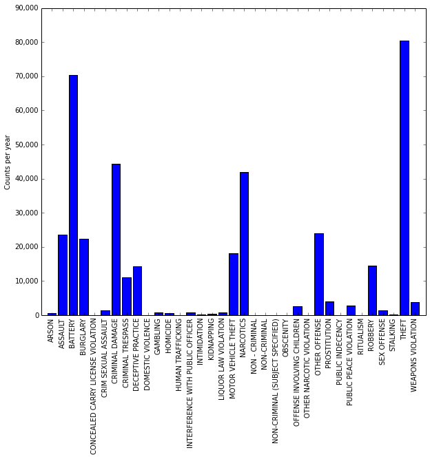

```python
counts = Counter(df['Primary Type'])
plot_counter(counts, sample_frac=1,yearly=True)
```

### Crime rate by year

Overall crime rate is falling steadily from 2001.

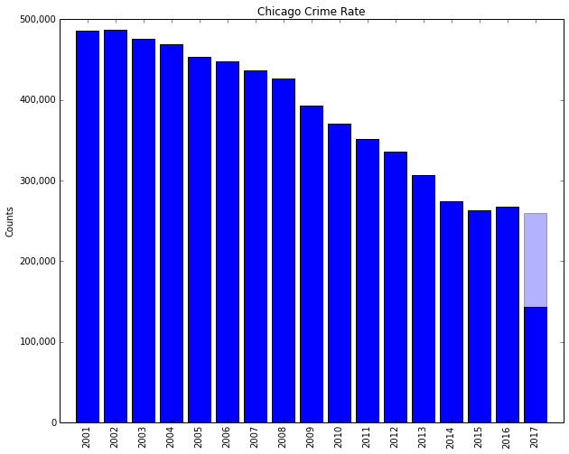

```python
ym = [i.strftime('%Y') for i in df['Date']]
counts = Counter(ym)
ax = plot_counter(counts, sample_frac=1, last_year=True)
ax.set_title('Chicago Crime Rate')
```

### Homicide in Chicago by year

A large increase in homicides can be sean in 2016 and 2017.

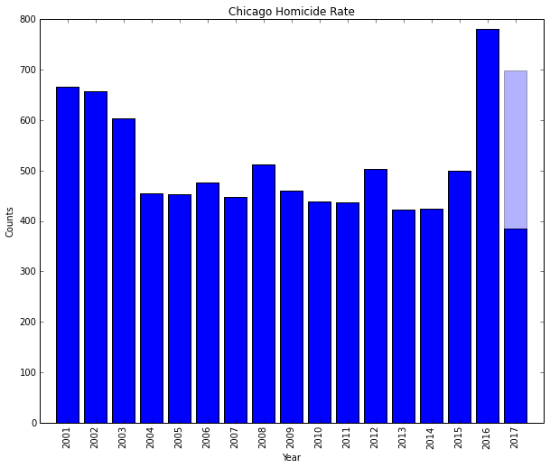

```python
# Chicago homicide rate
ym = [i.strftime('%Y') for i in df['Date'][df['Primary Type']=='HOMICIDE']]
counts = Counter(ym)
ax = plot_counter(counts, sample_frac=1, last_year=True)
ax.set_xlabel('Year')
ax.set_title('Chicago Homicide Rate')
```

Homicide rate is usually higher during the summer months.

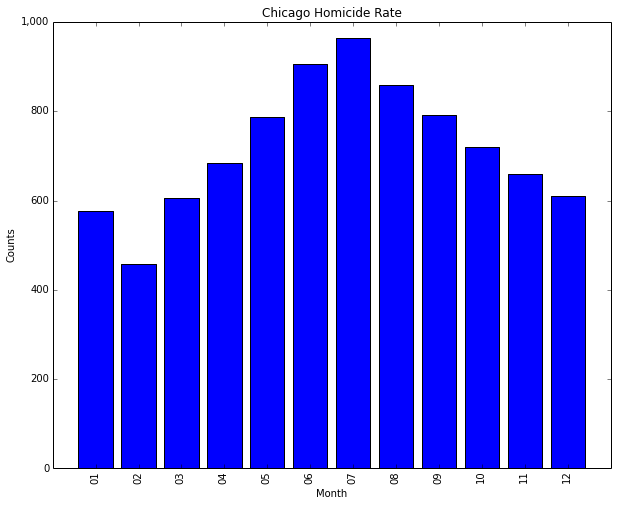

```python
# Chicago homicide rate
ym = [i.strftime('%m') for i in df['Date'][df['Primary Type']=='HOMICIDE']]
counts = Counter(ym)
ax = plot_counter(counts, sample_frac=1)
ax.set_xlabel('Month')
ax.set_title('Chicago Homicide Rate')
```

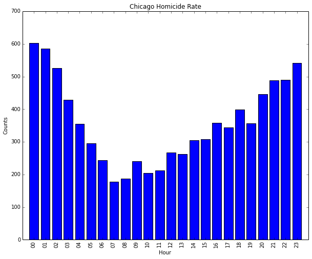

```python
# Chicago homicide rate
ym = [i.strftime('%H') for i in df['Date'][df['Primary Type']=='HOMICIDE']]
counts = Counter(ym)
ax = plot_counter(counts, sample_frac=1)
ax.set_xlabel('Hour')
ax.set_title('Chicago Homicide Rate')
```

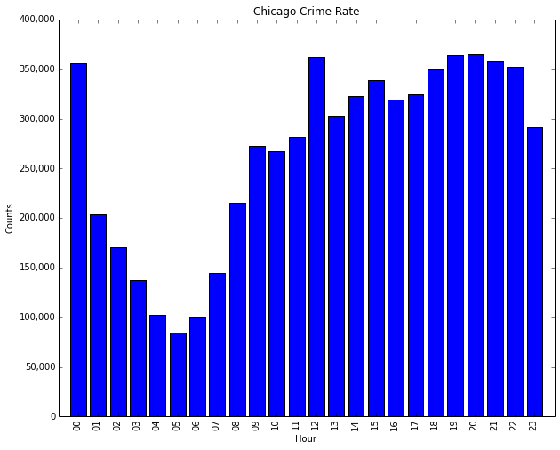

```python
ym = [i.strftime('%H') for i in df['Date']]
counts = Counter(ym)
ax = plot_counter(counts, sample_frac=1)
ax.set_xlabel('Hour')
ax.set_title('Chicago Crime Rate')
```

Domestic homicide does not seem to have increased after 2016. (2017 rate is the predicted rate for the entire year)

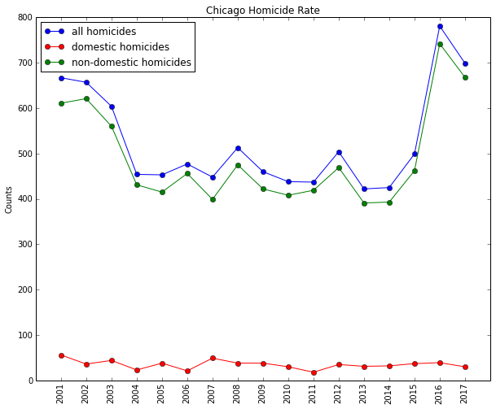

```python
# Chicago homicide rate
ax = None

filter = (df['Primary Type']=='HOMICIDE')
ym = [i.strftime('%Y') for i in df['Date'][filter]]
counts = Counter(ym)
ax = plot_counter(counts,
                  sample_frac=1,
                  last_year=True,
                  dot=True,
                  color='b',
                  label='all homicides',
                  ax=ax)

filter = (df['Primary Type']=='HOMICIDE') & (df['Domestic'])
ym = [i.strftime('%Y') for i in df['Date'][filter]]
counts = Counter(ym)
ax = plot_counter(counts,
                  sample_frac=1,
                  last_year=True,
                  dot=True,
                  color='r',
                  label='domestic homicides',
                  ax=ax)

filter = (df['Primary Type']=='HOMICIDE') & (df['Domestic']==False)
ym = [i.strftime('%Y') for i in df['Date'][filter]]
counts = Counter(ym)
ax = plot_counter(counts,
                  sample_frac=1,
                  last_year=True,
                  dot=True,
                  color='g',
                  label='non-domestic homicides',
                  ax=ax)

plt.legend(loc=0)
ax.set_title('Chicago Homicide Rate')
```

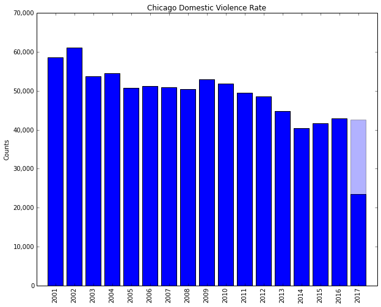

```python
# Chicago domestic violence rate
ym = [i.strftime('%Y') for i in df['Date'][df['Domestic']]]
counts = Counter(ym)
ax = plot_counter(counts, sample_frac=1, last_year=True)
ax.set_title('Chicago Domestic Violence Rate')
```

Non-homicide Weapons violation has increased in 2017 and has been falling in a slower rate that other crimes.

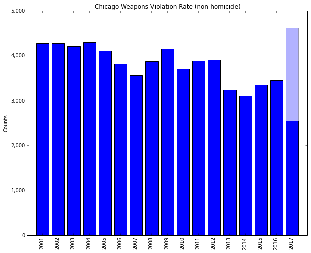

```python
# Chicago domestic violence rate
ym = [i.strftime('%Y') for i in df['Date'][df['Primary Type']=='WEAPONS VIOLATION']]
counts = Counter(ym)
ax = plot_counter(counts, sample_frac=1, last_year=True)
ax.set_title('Chicago Weapons Violation Rate (non-homicide)')
```

```
(1.0, 300000.0)
```

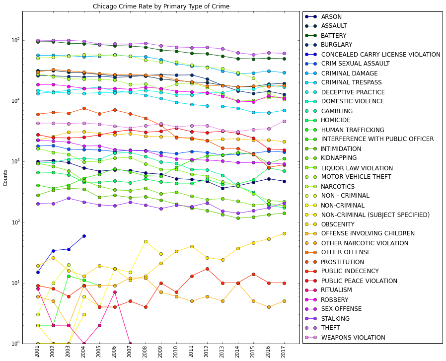

```python
ptype_list = np.unique(df['Primary Type'])
color_num = np.linspace(0, 230, len(ptype_list))

fig = plt.figure(figsize=(10,12))
ax = fig.add_subplot(111)
for c, ptype in  zip(color_num, ptype_list):
    ym = [i.strftime('%Y') for i in df['Date'][df['Primary Type']==ptype]]
    counts = Counter(ym)
    ax = plot_counter(counts,
                      sample_frac=1,
                      last_year=True,
                      dot=True,
                      color=plt.cm.gist_ncar(int(c)),
                      label=ptype,
                      ax=ax)

ax.semilogy()
ax.legend(loc='center left', bbox_to_anchor=(1,0.5))
ax.set_title('Chicago Crime Rate by Primary Type of Crime')
ax.set_ylim(1e0,3e5)
```

Even though homicide rates have been increasing in the past 2 years. Arrests associated with homicide have been decreasing. (I believe these are only data from arrests on scene)

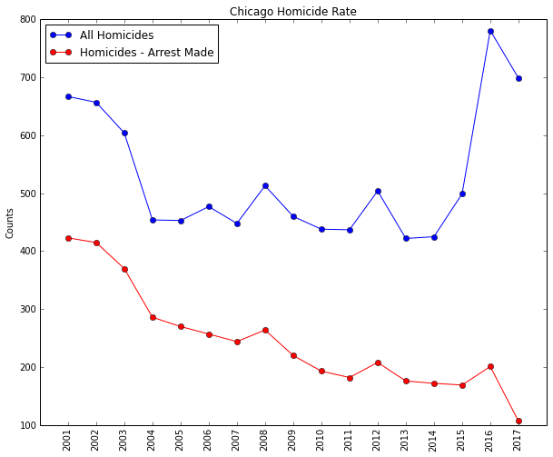

```python
# Chicago homicide rate
ax = None

filter = (df['Primary Type']=='HOMICIDE')
ym = [i.strftime('%Y') for i in df['Date'][filter]]
counts = Counter(ym)
ax = plot_counter(counts,
                  sample_frac=1,
                  last_year=True,
                  dot=True,
                  color='b',
                  label='All Homicides',
                  ax=ax)

filter = (df['Primary Type']=='HOMICIDE') & (df['Arrest'])
ym = [i.strftime('%Y') for i in df['Date'][filter]]
counts = Counter(ym)
ax = plot_counter(counts,
                  sample_frac=1,
                  last_year=True,
                  dot=True,
                  color='r',
                  label='Homicides - Arrest Made',
                  ax=ax)


plt.legend(loc=0)
ax.set_title('Chicago Homicide Rate')
```

Arrest in domestic homicides are dropped in 2016-2017 (75%) compared to the previous years (95% in 2001-2015) but it's not statistically significant. While for non-domestic homicides the rate has dropped from 48% in 2001-2015 to less than 20% in 2016-2017.

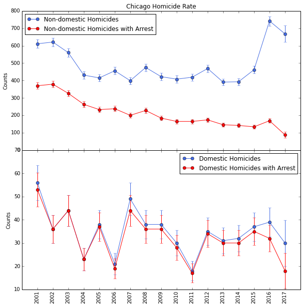

```python
fig, (ax1, ax2) = plt.subplots(2,
                               sharex=True,
                               sharey=False,
                               figsize=(10,10))

filter = (df['Primary Type']=='HOMICIDE') &\
         (df['Domestic']==False)
ym = [i.strftime('%Y') for i in df['Date'][filter]]
counts = Counter(ym)
ax1 = plot_counter(counts,
                   sample_frac=1,
                   last_year=True,
                   dot=True,
                   err=True,
                   color='royalblue',
                   label='Non-domestic Homicides',
                   ax=ax1)
filter = (df['Primary Type']=='HOMICIDE') &\
         (df['Domestic']==False) &\
         (df['Arrest'])
ym = [i.strftime('%Y') for i in df['Date'][filter]]
counts = Counter(ym)
ax1 = plot_counter(counts,
                   sample_frac=1,
                   last_year=True,
                   dot=True,
                   err=True,
                   color='red',
                   label='Non-domestic Homicides with Arrest',
                   ax=ax1)


filter = (df['Primary Type']=='HOMICIDE') &\
         (df['Domestic'])
ym = [i.strftime('%Y') for i in df['Date'][filter]]
counts = Counter(ym)
ax2 = plot_counter(counts,
                   sample_frac=1,
                   last_year=True,
                   dot=True,
                   err=True,
                   color='royalblue',
                   label='Domestic Homicides',
                   ax=ax2)
filter = (df['Primary Type']=='HOMICIDE') &\
         (df['Domestic']) &\
         (df['Arrest'])
ym = [i.strftime('%Y') for i in df['Date'][filter]]
counts = Counter(ym)
ax2 = plot_counter(counts,
                   sample_frac=1,
                   last_year=True,
                   dot=True,
                   err=True,
                   color='red',
                   label='Domestic Homicides with Arrest',
                   ax=ax2)



fig.subplots_adjust(hspace=0)
ax1.legend(loc=0)
ax2.legend(loc=0)
ax1.set_title('Chicago Homicide Rate')
```

```
(0, 500000.0)
```

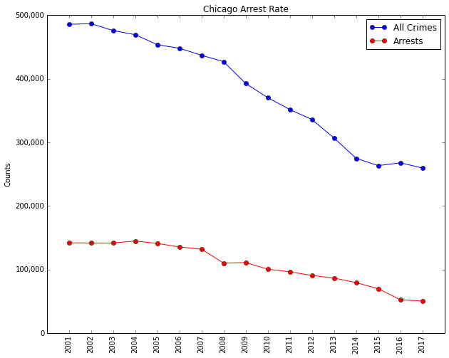

```python
# Chicago arrest rate
ax = None

ym = [i.strftime('%Y') for i in df['Date']]
counts = Counter(ym)
ax = plot_counter(counts,
                  sample_frac=1,
                  last_year=True,
                  dot=True,
                  err=True,
                  color='royalblue',
                  label='All Crimes',
                  ax=ax)

filter = (df['Arrest'])
ym = [i.strftime('%Y') for i in df['Date'][filter]]
counts = Counter(ym)
ax = plot_counter(counts,
                  sample_frac=1,
                  last_year=True,
                  dot=True,
                  err=True,
                  color='red',
                  label='Arrests',
                  ax=ax)


plt.legend(loc=0)
ax.set_title('Chicago Arrest Rate')
ax.set_ylim(0, 5e5)
```

Arrests related to non-homicide weapons violation is decreased slightly from 81% in 2001-2015 to 76% in 2016-2017.

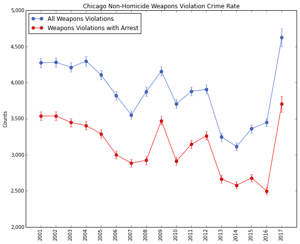

```python
ax = None

filter = (df['Primary Type']=='WEAPONS VIOLATION')
ym = [i.strftime('%Y') for i in df['Date'][filter]]
counts = Counter(ym)
ax = plot_counter(counts,
                  sample_frac=1,
                  last_year=True,
                  dot=True,
                  err=True,
                  color='royalblue',
                  label='All Weapons Violations',
                  ax=ax)

filter = (df['Primary Type']=='WEAPONS VIOLATION') &\
         (df['Arrest'])
ym = [i.strftime('%Y') for i in df['Date'][filter]]
counts = Counter(ym)
ax = plot_counter(counts,
                  sample_frac=1,
                  last_year=True,
                  dot=True,
                  err=True,
                  color='red',
                  label='Weapons Violations with Arrest',
                  ax=ax)

fig.subplots_adjust(hspace=0)
ax.legend(loc=0)
ax.set_title('Chicago Non-Homicide Weapons Violation Crime Rate')
```

```python
print(np.unique(df['Primary Type']))
```

```
['ARSON' 'ASSAULT' 'BATTERY' 'BURGLARY' 'CONCEALED CARRY LICENSE VIOLATION'
 'CRIM SEXUAL ASSAULT' 'CRIMINAL DAMAGE' 'CRIMINAL TRESPASS'
 'DECEPTIVE PRACTICE' 'DOMESTIC VIOLENCE' 'GAMBLING' 'HOMICIDE'
 'HUMAN TRAFFICKING' 'INTERFERENCE WITH PUBLIC OFFICER' 'INTIMIDATION'
 'KIDNAPPING' 'LIQUOR LAW VIOLATION' 'MOTOR VEHICLE THEFT' 'NARCOTICS'
 'NON - CRIMINAL' 'NON-CRIMINAL' 'NON-CRIMINAL (SUBJECT SPECIFIED)'
 'OBSCENITY' 'OFFENSE INVOLVING CHILDREN' 'OTHER NARCOTIC VIOLATION'
 'OTHER OFFENSE' 'PROSTITUTION' 'PUBLIC INDECENCY' 'PUBLIC PEACE VIOLATION'
 'RITUALISM' 'ROBBERY' 'SEX OFFENSE' 'STALKING' 'THEFT' 'WEAPONS VIOLATION']
```

```python
# choosing some of the primry types only
ptype_list =['ARSON', 'ASSAULT', 'BATTERY', 'BURGLARY',
             'CRIM SEXUAL ASSAULT', 'CRIMINAL DAMAGE', 'CRIMINAL TRESPASS',
             'DECEPTIVE PRACTICE', 'GAMBLING', 'HOMICIDE',
             'INTERFERENCE WITH PUBLIC OFFICER', 'INTIMIDATION',
             'KIDNAPPING', 'LIQUOR LAW VIOLATION', 'MOTOR VEHICLE THEFT',
             'NARCOTICS', 'OBSCENITY', 'OFFENSE INVOLVING CHILDREN',
             'OTHER NARCOTIC VIOLATION', 'OTHER OFFENSE', 'PROSTITUTION',
             'PUBLIC INDECENCY', 'PUBLIC PEACE VIOLATION', 'ROBBERY',
             'SEX OFFENSE', 'STALKING', 'THEFT', 'WEAPONS VIOLATION']
```

[figure not shown]

```python
def plot_share_segment(ax_, pType):
    filter = (df['Primary Type']==pType)
    ym = [i.strftime('%Y') for i in df['Date'][filter]]
    counts = Counter(ym)
    ax_ = plot_counter(counts,
                       sample_frac=1,
                       last_year=True,
                       dot=True,
                       err=True,
                       color='royalblue',
                       label='All ' + pType,
                       ax=ax_)

    filter = (df['Primary Type']==pType) &\
             (df['Arrest'])
    ym = [i.strftime('%Y') for i in df['Date'][filter]]
    counts = Counter(ym)
    ax_ = plot_counter(counts,
                       sample_frac=1,
                       last_year=True,
                       dot=True,
                       err=True,
                       color='red',
                       label=pType + ' with Arrest',
                       ax=ax_)

    ax_.legend(loc=0)

    return ax_

fig, ax = plt.subplots(len(ptype_list),
                     sharex=True,
                     sharey=False,
                     figsize=(10,len(ptype_list)*4))

for i, cType in enumerate(ptype_list):
    ax[i] = plot_share_segment(ax[i], cType)

fig.subplots_adjust(hspace=0)
```

District 11 has the most number of homicides in the past 4 years. Find districts' map here: https://data.cityofchicago.org/Public-Safety/Boundaries-Police-Districts-current-/fthy-xz3r

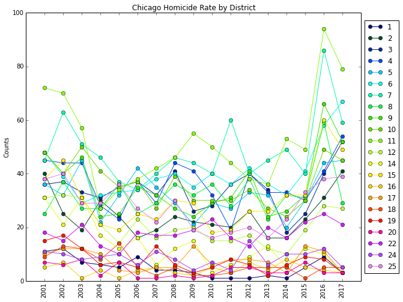

```python
ptype_list = np.unique(df['District'][df['Primary Type']=='HOMICIDE'])
color_num = np.linspace(0, 230, len(ptype_list))

ax = None
for c, ptype in  zip(color_num, ptype_list):
    filter = (df['District']==ptype) & (df['Primary Type']=='HOMICIDE')
    ym = [i.strftime('%Y') for i in df['Date'][filter]]
    counts = Counter(ym)
    ax = plot_counter(counts,
                      sample_frac=1,
                      last_year=True,
                      dot=True,
                      color=plt.cm.gist_ncar(int(c)),
                      label=int(ptype),
                      ax=ax)

ax.legend(loc='center left', bbox_to_anchor=(1,0.5))
ax.set_title('Chicago Homicide Rate by District')
```

District 15 has the highest increase from (2005-2007) to (2016-2017) with 151% increase followed by district 11 with 134%.

```python
hChange = np.array([])
hChangeErr = np.array([])
aChange = np.array([])
aChangeErr = np.array([])

distrtic_list = np.unique(df['District'][df['Primary Type']=='HOMICIDE'])

frac = (max(df_sample['Date']) -
        pd.tslib.Timestamp('2017-01-01 00:00:00')) / np.timedelta64(365, 'D')

print('Change in homicide rate from (2005-2007) to\n' +
      '(2016-2017) in percent:')
print('\t\t\t\tAvg counts\tAvg counts\tChange in')
print('\t\t\t\tin 2005-2007\tin 2016-2017\tarrest')
print('Dist.\t% +/- uncertainty\tper year\tper year\t%')

for distrtic in distrtic_list:
    filter = (df['District']==distrtic) & (df['Primary Type']=='HOMICIDE')
    ym = [i.strftime('%Y') for i in df['Date'][filter]]
    counts = Counter(ym)

    base = counts['2005'] + counts['2006'] + counts['2007']
    avg_base = base / 3.0
    surge = counts['2016'] + counts['2017']
    avg_surge = surge / (1 + frac)
    percent_change = 100 * (avg_surge - avg_base)/avg_base
    err = percent_change * np.sqrt((1. / (surge + base)) +\
                                   (1. / (base)))
    hChange = np.append(hChange, percent_change)
    hChangeErr = np.append(hChangeErr, err)

    filter = (df['District']==distrtic) & (df['Primary Type']=='HOMICIDE') &\
             (df['Arrest'])
    ym = [i.strftime('%Y') for i in df['Date'][filter]]
    counts = Counter(ym)

    arr_base = counts['2005'] + counts['2006'] + counts['2007']
    arr_per_base = 1.0 * arr_base / base
    arr_surge = counts['2016'] + counts['2017']
    arr_per_surge = 1.0 * arr_surge / surge
    arr_change = arr_per_surge - arr_per_base
    arr_percent_change = 100 * arr_change
    err_a = abs(arr_percent_change) * np.sqrt((1. / (1 if arr_base==0 else arr_base)) +\
                          (1. / base) +\
                          (1. / (1 if arr_surge==0 else arr_surge)) +\
                          (1. / surge))
    aChange = np.append(aChange, arr_percent_change)
    aChangeErr = np.append(aChangeErr, err_a)

    print(str(int(distrtic)) + '\t' +\
          '{:0.1f}'.format(percent_change) + '\t' +\
          '{:0.1f}'.format(err) +'\t\t' +\
          '{:0.1f}'.format(avg_base) + '\t\t' +\
          '{:0.1f}'.format(avg_surge) + '\t\t' +\
          '{:0.1f}'.format(arr_percent_change))
```

```
Change in homicide rate from (2005-2007) to
(2016-2017) in percent:
				Avg counts	Avg counts	Change in
				in 2005-2007	in 2016-2017	arrest
Dist.	% +/- uncertainty	per year	per year	%
1	18.2	5.5		6.0		7.1		-10.6
2	77.1	12.4		19.7		34.8		-36.6
3	28.4	3.5		34.7		44.5		-21.0
4	54.3	7.2		29.7		45.8		-32.8
5	22.5	2.7		36.3		44.5		-24.9
6	75.0	9.0		35.0		61.3		-36.0
7	107.4	12.4		37.0		76.7		-26.7
8	61.2	8.0		30.0		48.4		-33.6
9	99.8	12.7		30.7		61.3		-18.4
10	44.6	5.6		33.0		47.7		-36.0
11	134.2	15.1		38.0		89.0		-42.2
12	57.0	9.7		17.7		27.7		-33.2
14	-31.7	-7.2		11.3		7.7		-19.6
15	151.2	22.1		22.3		56.1		-56.4
16	16.1	6.5		3.3		3.9		-13.3
17	109.6	38.5		4.0		8.4		-28.8
18	-26.3	-7.5		7.0		5.2		-70.2
19	-22.6	-5.9		8.3		6.4		-36.0
20	7.5	3.2		3.0		3.2		-88.9
22	59.1	11.0		15.0		23.9		-27.7
24	7.5	1.8		9.0		9.7		-25.9
25	36.6	5.0		28.3		38.7		-33.0
```

Fitting a linear line in homicide rate change vs arrest change rate.

```python
def f(B,x):
    '''linear function y = m*x + b'''
    return B[0] * x + B[1]

linear = scipy.odr.Model(f)
myData = scipy.odr.RealData(hChange, aChange,
                            sx=hChangeErr,
                            sy=aChangeErr)

myodr = scipy.odr.ODR(myData, linear, beta0=[0., 0.])

myoutput = myodr.run()

myoutput.pprint()
```

```
Beta: [ -0.08919985 -19.43031743]
Beta Std Error: [ 0.04869692  3.32696525]
Beta Covariance: [[  2.94100721e-03  -1.61790144e-01]
 [ -1.61790144e-01   1.37274407e+01]]
Residual Variance: 0.806319110408
Inverse Condition #: 0.00865146103035
Reason(s) for Halting:
  Sum of squares convergence
```

Districts with largest increase in homicide rate had the larges decrease in arrest associated with homicide.

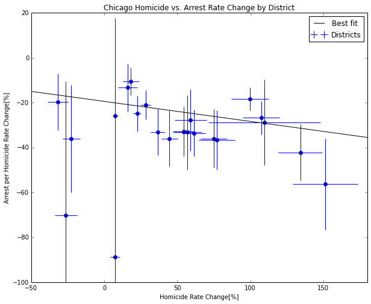

```python
fig = plt.figure(figsize=(10,8))
ax = fig.add_subplot(111)

ax.plot(hChange, aChange, 'o', color='b')
ax.errorbar(hChange, aChange,
            xerr=hChangeErr,
            yerr=aChangeErr,
            fmt=None,
            capsize=0,
            color='b',
            label='Districts')

x_fit = np.linspace(-50, 200, 10)
y_fit = f(myoutput.beta, x_fit)
ax.plot(x_fit,y_fit, '-',
        color='k',
        label='Best fit')

ax.set_xlabel('Homicide Rate Change[%]')
ax.set_ylabel('Arrest per Homicide Rate Change[%]')

ax.set_xlim(-50,180)
ax.set_ylim(-100,20)

ax.legend(loc=0)
ax.set_title('Chicago Homicide vs. Arrest Rate Change by District')
```

Calculating the aboslute change in homicide rate.

```python
hAbsChange = np.array([])
hAbsChangeErr = np.array([])
aAbsChange = np.array([])
aAbsChangeErr = np.array([])

distrtic_list = np.unique(df['District'][df['Primary Type']=='HOMICIDE'])

frac = (max(df_sample['Date']) -
        pd.tslib.Timestamp('2017-01-01 00:00:00')) / np.timedelta64(365, 'D')

for distrtic in distrtic_list:
    filter = (df['District']==distrtic) & (df['Primary Type']=='HOMICIDE')
    ym = [i.strftime('%Y') for i in df['Date'][filter]]
    counts = Counter(ym)

    base = counts['2005'] + counts['2006'] + counts['2007']
    avg_base = base / 3.0
    surge = counts['2016'] + counts['2017']
    avg_surge = surge / (1. + frac)
    avg_change = avg_surge - avg_base
    err = np.sqrt((surge / ((1 + frac) * (1 + frac))) +\
                  (base / 9.))

    hAbsChange = np.append(hAbsChange, avg_change)
    hAbsChangeErr = np.append(hAbsChangeErr, err)

    filter = (df['District']==distrtic) & (df['Primary Type']=='HOMICIDE') &\
             (df['Arrest'])
    ym = [i.strftime('%Y') for i in df['Date'][filter]]
    counts = Counter(ym)

    arr_base = counts['2005'] + counts['2006'] + counts['2007']
    arr_avg_base = arr_base / 3.
    arr_surge = counts['2016'] + counts['2017']
    arr_avg_surge = arr_surge / (1 + frac)
    arr_change = arr_avg_surge - arr_avg_base

    err_a = np.sqrt((arr_surge / ((1 + frac) * (1 + frac))) +\
                  (arr_base / 9.))
    aAbsChange = np.append(aAbsChange, arr_change)
    aAbsChangeErr = np.append(aAbsChangeErr, err_a)
```

Fitting a linear line to it.

```python
def f(B,x):
    '''linear function y = m*x + b'''
    return B[0] * x + B[1]

linear = scipy.odr.Model(f)
myData = scipy.odr.RealData(hAbsChange, aAbsChange,
                            sx=hAbsChangeErr,
                            sy=aAbsChangeErr)

myodr = scipy.odr.ODR(myData, linear, beta0=[1., 2.])

myoutput = myodr.run()

myoutput.pprint()
```

```
Beta: [-0.1137484  -2.47451724]
Beta Std Error: [ 0.05056099  0.61523174]
Beta Covariance: [[ 0.00198747 -0.01106147]
 [-0.01106147  0.29427006]]
Residual Variance: 1.28626779596
Inverse Condition #: 0.0750227385719
Reason(s) for Halting:
  Sum of squares convergence
```

Data give similar answer as the plot above; Districts with largest increase in homicide rate had the larges decrease in arrest associated with homicide.

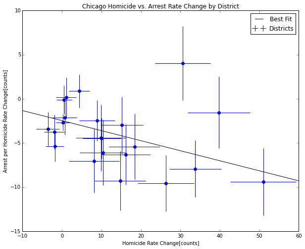

```python
fig = plt.figure(figsize=(10,8))
ax = fig.add_subplot(111)

ax.plot(hAbsChange, aAbsChange, 'o', color='b')
ax.errorbar(hAbsChange, aAbsChange,
            xerr=hAbsChangeErr,
            yerr=aAbsChangeErr,
            fmt=None,
            capsize=0,
            color='b',
            label='Districts')

x_fit = np.linspace(-10, 60, 10)
y_fit = f(myoutput.beta, x_fit)
ax.plot(x_fit,y_fit, '-',
        color='k',
        label='Best Fit')

ax.set_xlabel('Homicide Rate Change[counts]')
ax.set_ylabel('Arrest per Homicide Rate Change[counts]')

ax.legend(loc=0)
ax.set_title('Chicago Homicide vs. Arrest Rate Change by District')
```

Even though lower number crimes can be correlated to the lower number of arrest in Chicago (each can cause the other), but lower percentage and even number of arrests related to homicides during the increase of homicide rate (these correlations are relatively small and not conclusive) in the past few years can questionable. Note that data for arrests are only arrests at the the scene and the arrests made later are not in this data.